# Section 2: Summarizing random variables

Trevor Incerti

12 September 2019

## R, R Markdown, LaTeX

- Questions, problems, or concerns?
- Please attempt to have R and R Markdown running by section next week (you still do not need to use R or Markdown for this week’s problem set).
- Feel free to stop by office hours, set up an individual appointment, or drop by the Stat Lab if you are having trouble.

## Summarizing random variables

- Definition of a random variable: a variable that takes on a real value that is determined by a random generative process.
- A random variable is neither random nor a variable.
- Placeholder for a quantity that has yet to be determine by a random generative process (function).
- A random variable is a function.
- A random variable’s possible values might represent the possible outcomes of a yet-to-be-performed experiment, the results of a random process such as rolling a die, or the “subjective” randomness that results from incomplete knowledge of a quantity.
- How can we summarize random variables?

### Probability Mass Functions

- Summarizes the probability of each outcome $x$ occuring.
- A *function* that describes the probability that a *discrete* random variable is exactly equal to some value. The PMF maps possible outcomes of a random variable to the corresponding probabilities of that outcome occuring.
- How much “stuff” is there associated with a given event?
- All probabilities add up to 1.

*Example formalization*

Below is the probability mass function of an unfair die, where we observe a 1, 2, or 3 with probability $\frac{1}{12}$, and a 4, 5, or 6 with probability $\frac{1}{4}$. The PMF can therefore be defined as:

$$\begin{equation}
f(x) =
\begin{cases}
\frac{1}{12} & : x = 1 \\
\frac{1}{12} & : x = 2 \\
\frac{1}{12} & : x = 3 \\
\frac{1}{4} & : x = 4 \\
\frac{1}{4} & : x = 5 \\
\frac{1}{4} & : x = 6 \\
0 & : otherwise \\
\end{cases}
\end{equation}$$

What is $Pr[X \geq 2]$?

$$Pr[X \geq 2] =$$
$$\sum_{x = 2}^6 f(x) =$$
$$\frac{1}{12} + \frac{1}{12} + \frac{1}{4} + \frac{1}{4} + \frac{1}{4} =$$
$$\frac{11}{12}$$

*Example visualization*

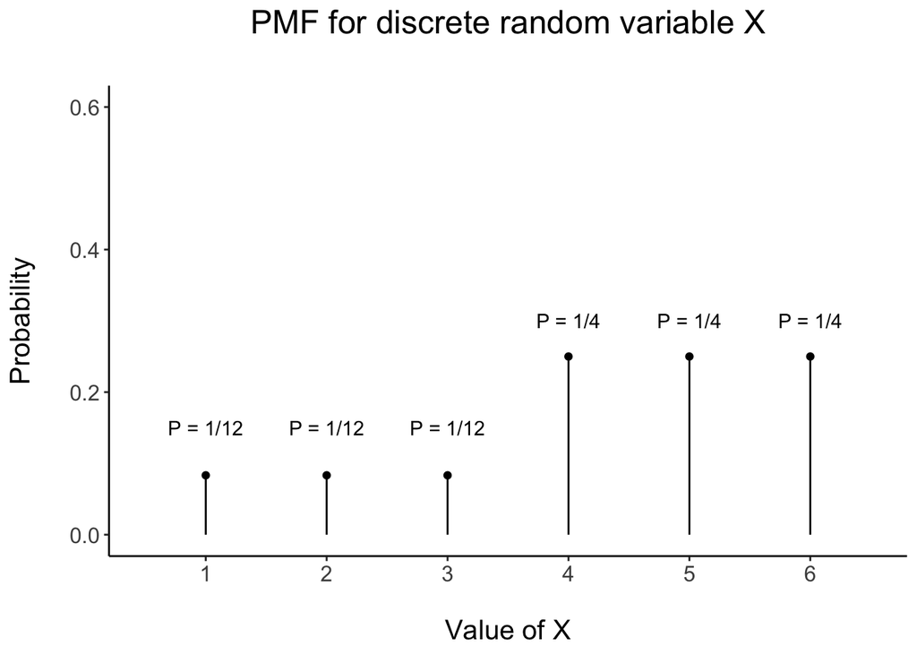

### Cumulative Distribution Functions

- Describes the distribution of all random variables, not just discrete random variables (i.e. can be discrete or continuous).
- Describes the probability that a random variable $X$ will take a value less than or equal to $x$.
- How much “stuff” is there to the left of a point?

*Example visualizations*

- Discrete CDF will have “jumps” or “steps.”
- Unfair die again:

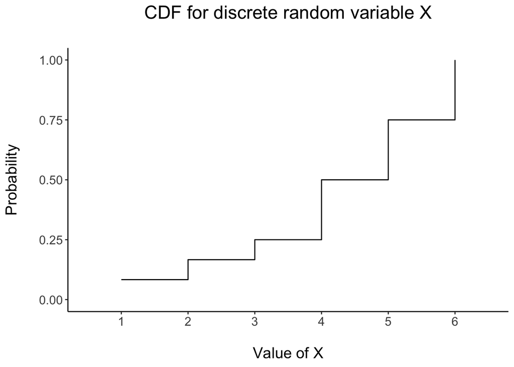

- Continuous CDF is smooth. Example: standard normal distribution.

$$\Phi(x) = \int_{-\infty}^{x} \frac{1}{\sqrt{2\pi}}e^\frac{-u^2}{2}du$$

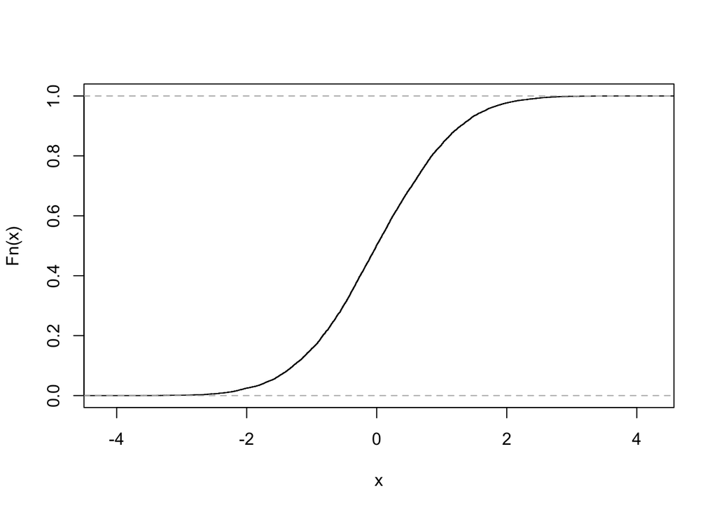

### Probability Density Functions

- The PDF specifies the probability of a random variable falling within a particular range of values (sand), as opposed to taking on any one value (sticks). The PDF therefore allows us to answer the question: how much of the distribution of a random variable is found in the filled area? In other words, how much probability mass is there between observations in a given range?
- The probability of a random variable falling within a particular range of values is therefore given by the integral of this variable’s PDF over that range.
- What is the absolute likelihood a continuous random variable takes on any particular value? Why?
- The probability density function is nonnegative everywhere, and its integral over the entire space is equal to one.
- The PDF is the derivative of the CDF. This is why the the slope of the CDF is greatest at the highest point of the PDF.

*Example visualization*

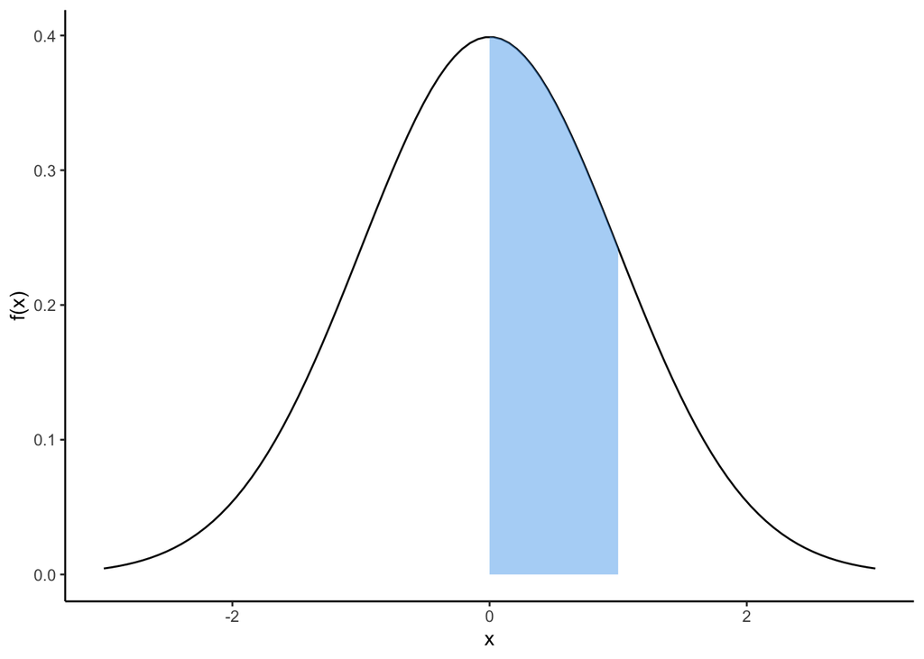

### Practice Problems

1.) Suppose you are conducting a survey about access to education in a village with 100 families. 30 families have 1 child, 50 families have 2 children, and 20 families have 3 children. The birth rank of one of these children is 1 if the child is the firstborn, 2 if the child is the second born, and 3 if the child is the third born.

- A random family is chosen (with equal probabilities), and then a random child within that family is chosen (with equal probabilities) to be interviewed. Find the PMF of the child’s birth rank.
- A random child is chosen in the town (with equal probabilities). Find the PMF and draw the CDF of the childs birth rank.

*Part 1 solution*

$$f(1)=0.3∗1+0.5∗0.5+0.2∗(1/3)≈0.617$$
$$f(2)=0.3∗0+0.5∗0.5+0.2∗(1/3)≈0.317$$
$$f(3)=0.3∗0+0.5∗0+0.2∗(1/3)≈0.067$$

$$\begin{equation}
f(x) =
\begin{cases}
0.617 & : x = 1 \\
0.317 & : x = 2 \\
0.067 & : x = 3 \\
0 & : otherwise \\
\end{cases}
\end{equation}$$

*Part 2 solution*

PMF of Y, birth rank under individual level sampling:

$$\begin{equation}
f(x) =
\begin{cases}
\frac{100}{190} & : x = 1 \\
\frac{70}{190} & : x = 2 \\
\frac{20}{190} & : x = 3 \\
0 & : otherwise \\
\end{cases}
\end{equation}$$

2.) Let $X$ be a random variable with CDF $F$, let $Y = a + b X$, with $a$ and $b$ real, $> 0$. The CDF $X$ is $F_x$ and the CDF of $Y$ is $F_y$. What is the CDF of $F_y$ in terms of $F_x$?

*Solution*

The CDF of $Y$ at a point $y$ is the probability that $Y$ takes on any value less than or equal to $y$, or $Pr[Y \leq y]$

In terms of $F_x$, the CDF of $Y$ is:

$$F_y = Pr[Y \leq y]=$$
$$Pr[a+bX \leq y] =$$
$$Pr[X \leq \frac{y − a}{b}]$$

$$= F_x(\frac{y − a}{b})$$

CDFs are functions that can be manipulated.

3.) A marksman takes 10 shots at a target and has probability 0.2 of hitting the target with each shot, independently of all other shots. Let $X$ be the number of hits. Calculate and sketch the PMF of X.

*Hint:* The binomial distribution is a discrete probability distribution of the successes in a sequence of $n$ independent yes/no outcomes, and the probability of getting exactly $k$ successes in $n$ trials is given by the Probability Mass Function:

$$P(X = k) = {n \choose k}p^k(1-p)^{n-k}$$

In class we discussed the geometric distrubution $Pr(X = k) = (1-p)^{k-1}p$, which describes the number of successes $k$ until observing the first “failure.”

*Solution*

$X$ is a binomial random variable with $n = 10$, $p = 0.2$. Therefore,

$$\begin{equation}
P(X = k) =
\begin{cases}
{n \choose k}0.2^k 0.8^{10-k} & : x \in ℕ \\
0 & : otherwise \\
\end{cases}
\end{equation}$$

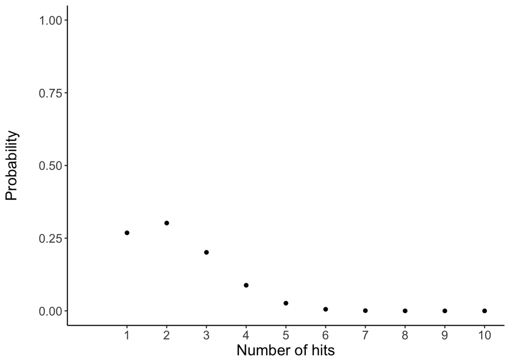

## Bivariate distributions

### Discrete marginal and conditional distributions

- The joint PMF shows us the probability that $X=x$ *and* $Y=y$ in a single realization of the random generative process.
- The joint CDF shows us the probability of observing $X \leq x$ and $Y \leq y$ in a single realization of the random generative process.

*Example:*

Assume some random vector $(X, Y)$ is characterized by the following joint PMF:

$$\begin{equation}
f(x,y) =
\begin{cases}
\frac{1}{3} & : x = 0, y = 0 \\
\frac{1}{3} & : x = 0, y = 1 \\
\frac{1}{6} & : x = 1, y = 1 \\
\frac{1}{6} & : x = 1, y = 2 \\
0 & : otherwise \\
\end{cases}
\end{equation}$$

Compute the following:

a.) $Pr[X = 1, Y = 1]$  
b.) $Pr[X = 1 | Y = 1]$  
c.) Supp$[X]$  
d.) The marginal PMF of $Y$

*Solutions*

|  | $X = 0$ | $X = 1$ | Marginal |
| --- | --- | --- | --- |
| $Y = 0$ | $\frac{2}{6}$ | $0$ | $\frac{2}{6}$ |
| $Y = 1$ | $\frac{2}{6}$ | $\frac{1}{6}$ | $\frac{3}{6}$ |
| $Y = 2$ | $0$ | $\frac{1}{6}$ | $\frac{1}{6}$ |
| Marginal | $\frac{4}{6}$ | $\frac{2}{6}$ |  |

a.) $\frac{1}{6}$. This is given to us in the joint PMF.

b.) Conditional probability = joint / marginal or $Pr[X = x | Y = y] = \frac{Pr[X = x, Y = y]}{Pr[Y = y]}$, so:

$$Pr[X = 1| Y = 1] =$$
$$\frac{Pr[X = 1, Y = 1]}{Pr[Y = 1]} =$$

$$\frac{\frac{1}{6}}{\frac{3}{6}} =$$

$$\frac{1}{3}$$

c.) Supp[X] = $\{0, 1\}$

d.)

$$\begin{equation}
f_Y(y) =
\begin{cases}
\frac{1}{3} & : y = 0 \\
\frac{1}{2} & : y = 1 \\
\frac{1}{6} & : y = 2 \\
0 & : otherwise \\
\end{cases}
\end{equation}$$

### Jointly continuous random variables

Effectively the same as the discrete case, except now instead of summing we are integrating.

*Example:* Consider the bivariate distribution whose joint PDF is:

$$f(x,y) = \frac{3(x^2 + y)}{11}, \forall x \in [0,2], y \in [0,1]$$
with $f(x,y) = 0$ elsewhere. This joint PDF is plotted below and is sometimes referred to as the “curved roof distribution.”

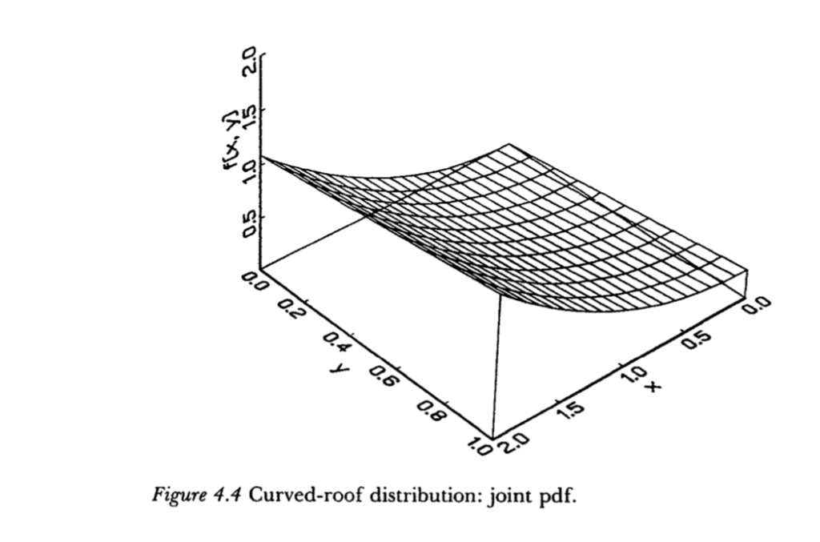

a.) Show that the marginal PDF of X is $f_X(x) = \frac{3(2x^2 + 1)}{22}, ∀x ∈ [0, 2]$ with $f_X(x) = 0$ elsewhere.

b.) Derive $f_{Y | X}(y|x)$, the conditional PDF of $Y$ given $X$, $∀x ∈ [0,2]$.

c.) Find $Pr[Y \leq 0.5|X = 1]$.

*Solutions:*

a.) Marginal PDF of Y of a jointly continuous random variable is: $f_Y(y) = \int_{-\infty}^{\infty} f(x,y)dx, \forall y \in ℝ$, so:

$$f_X(x) = \int_{0}^1 \left(\frac{3}{11}x^2 + \frac{3}{11}y \right)dy =$$
$$\frac{3}{11} \int_{0}^1 (x^2 + y)dy =$$
$$\frac{3}{11} (x^2y + \frac{1}{2}y^2)|_{0}^1 =$$

$$\frac{3}{11} (x^2 + \frac{1}{2} - 0) =$$
$$\frac{3x^2}{11} + \frac{3}{22} =$$

$$\frac{6x^2 + 3}{22} =$$
$$\frac{3(2x^2 + 1)}{22} =$$

b.) Derive $f_{Y | X}(y|x)$, the conditional PDF of $Y$ given $X$, $∀x ∈ [0,2]$.

$$f_{Y | X}(y|x) = \frac{f(x, y)}{f_X(x)}, \forall x \in [0,2] =$$

$$\frac{\frac{3(x^2 + y)}{11}}{\frac{3(2x^2 + 1)}{22}} =$$
$$2 \left( \frac{x^2 + y}{2x^2 + 1} \right)=$$
$$\frac{2x^2 + 2y}{2x^2 + 1}$$

c.) Now that we know the conditional PDF of Y given X from above:

$$f_{Y|X=1} = \int_{0}^{0.5} \frac{2(1)^2 + 2y}{2(1)^2 + 1}$$
$$f_{Y|X=1} = \int_{0}^{0.5} \frac{2 + 2y}{3} =$$
$$f_{Y|X=1} = \frac{2}{3} \int_{0}^{0.5} (1 +y)dy =$$

$$\frac{2}{3}\left[ y + \frac{1}{2}y^2 \right] |_0^{0.5}$$

$$\frac{2}{3}\left[ \frac{1}{2} + \frac{1}{2} \times \frac{1}{4} \right] =$$

$$\frac{5}{12}$$